# Homework6

Yen Wang and Nathan Frank

2/28/2022

Data cleaning: the values “IAP”, “DK” and “NA” all encode missing values. Replace all of these instances by the value NA.

```r
HAPPY = replace(HAPPY, HAPPY == "IAP", NA)
HAPPY = replace(HAPPY, HAPPY == "DK", NA)
HAPPY = replace(HAPPY, HAPPY == "NA", NA)
```

Check the type of the variable and cast into the right type (factor variable for categorical variables). For age, change “89 OR OLDER” to 89 and assume the variable should be numeric. Bring all levels of factors into a sensible order. For marital you could e.g. order the levels according to average age.

```r
str(HAPPY)
```

```
## 'data.frame':    62466 obs. of  11 variables:
##  $ HAPPY   : Factor w/ 3 levels "NOT TOO HAPPY",..: 1 1 2 1 2 2 1 1 2 2 ...
##  $ YEAR    : int  1972 1972 1972 1972 1972 1972 1972 1972 1972 1972 ...
##  $ AGE     : chr  "23" "70" "48" "27" ...
##  $ SEX     : chr  "FEMALE" "MALE" "FEMALE" "FEMALE" ...
##  $ MARITAL : chr  "NEVER MARRIED" "MARRIED" "MARRIED" "MARRIED" ...
##  $ DEGREE  : chr  "BACHELOR" "LT HIGH SCHOOL" "HIGH SCHOOL" "BACHELOR" ...
##  $ FINRELA : chr  "AVERAGE" "ABOVE AVERAGE" "AVERAGE" "AVERAGE" ...
##  $ HEALTH  : chr  "GOOD" "FAIR" "EXCELLENT" "GOOD" ...
##  $ WTSSALL : num  0.445 0.889 0.889 0.889 0.889 ...
##  $ PARTYID : chr  "IND,NEAR DEM" "NOT STR DEMOCRAT" "INDEPENDENT" "NOT STR DEMOCRAT" ...
##  $ POLVIEWS: chr  NA NA NA NA ...
```

```r
happy1 =
 HAPPY %>% mutate(AGE = replace(AGE, AGE == "89 OR OLDER", 89)) %>%
  mutate(AGE = as.numeric(AGE))
```

```r
happy1 = happy1 %>% mutate(SEX = as.factor(HAPPY))
```

```r
happy1 = happy1 %>% mutate(MARITAL = as.factor(MARITAL)) %>%
  mutate(MARITAL = factor(MARITAL, levels = c("NEVER MARRIED", "MARRIED", "SEPARATED", "DIVORCED", "WIDOWED")))
```

```r
happy1 = happy1 %>% mutate(FINRELA = as.factor(FINRELA)) %>%
  mutate(FINRELA = factor(FINRELA, levels = c("FAR BELOW AVERAGE","BELOW AVERAGE","AVERAGE","ABOVE AVERAGE","FAR ABOVE AVERAGE")))
```

```r
happy1 = happy1 %>% mutate(HEALTH = as.factor(HEALTH)) %>%
  mutate(HEALTH = factor(HEALTH, levels = c("POOR","FAIR","GOOD","EXCELLENT")))
```

```r
happy1 = happy1 %>% mutate(PARTYID = as.factor(PARTYID)) %>%
  mutate(PARTYID = factor(PARTYID, levels = c("STRONG REPUBLICAN", "NOT STR REPUBLICAN", "IND,NEAR REP", "INDEPENDENT", "IND,NEAR DEM", "NOT STR DEMOCRAT", "STRONG DEMOCRAT", "OTHER PARTY")))
```

```r
happy1 = happy1 %>% mutate(POLVIEWS = as.factor(POLVIEWS)) %>%
  mutate(POLVIEWS = factor(POLVIEWS, levels = c("EXTRMLY CONSERVATIVE", "CONSERVATIVE","SLIGHTLY CONSERVATIVE","MODERATE","SLIGHTLY LIBERAL","LIBERAL","EXTREMELY LIBERAL")))
```

```r
happy1 = happy1 %>% mutate(DEGREE = as.factor(DEGREE)) %>%
  mutate(DEGREE = factor(DEGREE, levels = c("LT HIGH SCHOOL", "HIGH SCHOOL", "JUNIOR COLLEGE", "BACHELOR", "GRADUATE")))
str(happy1)
```

```
## 'data.frame':    62466 obs. of  11 variables:
##  $ HAPPY   : Factor w/ 3 levels "NOT TOO HAPPY",..: 1 1 2 1 2 2 1 1 2 2 ...
##  $ YEAR    : int  1972 1972 1972 1972 1972 1972 1972 1972 1972 1972 ...
##  $ AGE     : num  23 70 48 27 61 26 28 27 21 30 ...
##  $ SEX     : Factor w/ 3 levels "NOT TOO HAPPY",..: 1 1 2 1 2 2 1 1 2 2 ...
##  $ MARITAL : Factor w/ 5 levels "NEVER MARRIED",..: 1 2 2 2 2 1 4 1 1 2 ...
##  $ DEGREE  : Factor w/ 5 levels "LT HIGH SCHOOL",..: 4 1 2 4 2 2 2 4 2 2 ...
##  $ FINRELA : Factor w/ 5 levels "FAR BELOW AVERAGE",..: 3 4 3 3 4 4 4 3 3 2 ...
##  $ HEALTH  : Factor w/ 4 levels "POOR","FAIR",..: 3 2 4 3 3 3 4 3 4 2 ...
##  $ WTSSALL : num  0.445 0.889 0.889 0.889 0.889 ...
##  $ PARTYID : Factor w/ 8 levels "STRONG REPUBLICAN",..: 5 6 4 6 7 5 5 5 7 7 ...
##  $ POLVIEWS: Factor w/ 7 levels "EXTRMLY CONSERVATIVE",..: NA NA NA NA NA NA NA NA NA NA ...
```

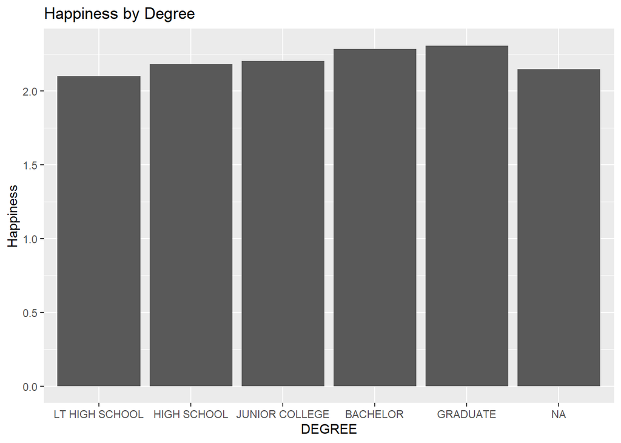

```r
#happiness by degree
happy.degree = happy1 %>%
  group_by(DEGREE) %>% summarise(m.degree = mean(as.numeric(HAPPY), na.rm = TRUE))

happy.degree %>% ggplot(aes(x = DEGREE)) + geom_bar(aes(weight = m.degree)) +
  labs(title="Happiness by Degree", y="Happiness")
```

The bar graph shows that happiness increases with a more advanced degree. The people who had bachelor and graduate degrees had an average happiness rating above a 2.25 on a 3 point scale, where as people with lt high school had the lowest happiness score. This trend makes sense because people with higher degrees can advance in their career more easily, and they most likely work in a specific field that they enjoy. The NA column has a happiness level near the lt high school level, so most of the NA column probably had a lower level of education.

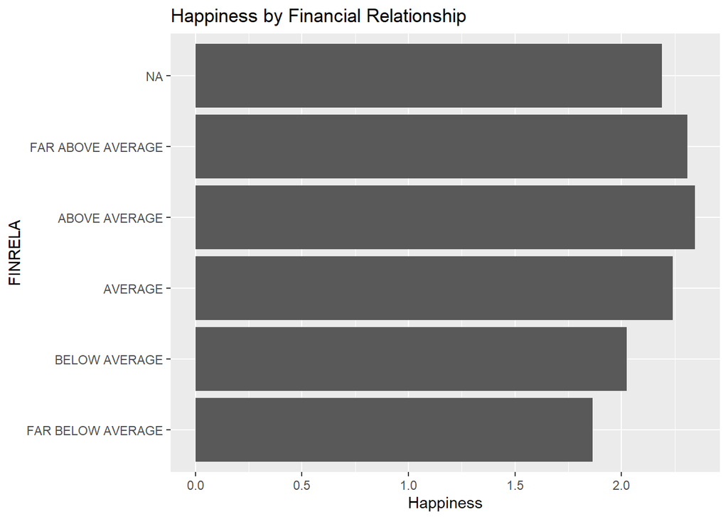

```r
#happiness by financial relationship
happy.finrela = happy1 %>%
  group_by(FINRELA) %>% summarise(m.finrela = mean(as.numeric(HAPPY), na.rm = TRUE))

happy.finrela %>% ggplot(aes(x = FINRELA)) + geom_bar(aes(weight = m.finrela)) +
  labs(title="Happiness by Financial Relationship", y="Happiness") + coord_flip()
```

The above graph shows the relationship between happiness level and financial status. From the bar graph we can see that people whoes financial relationship is above average are the happiest and the average happiness level of those whoes financial status is far below average is only around 1.875. Therefore, we can conclude that higher happiness level means higher financial relatinpship and it does play a big role on one’s happiness level.